# RHomework3

Sadiq Rahman

24/02/2021

```r
library(tidyverse)
library(factoextra)
```

# 2 Stoop, standing up, or sitting down

```r
stroop <- read_csv("stroop_standing_data.csv")
```

The data in it’s current form is *very* messy. We can start by mutating reaction time to a numerical value, not a categorical value. By doing so, we can omit all data where RT was not recorded (rt = FALSE). We cannot analyse reaction time is there are FALSE data.

```r
stroop <- mutate(stroop, rt = as.numeric(rt))
stroop <- filter(stroop, rt > 0)
```

Then, we omit all practice trials as these are not relevant for our analysis.

```r
stroop <- filter(stroop, phase != "practice")
```

Next, we omit all mistrials (correct = 999).

```r
stroop <- filter(stroop, correct < 2)
```

Finally, by changing the variable X11 to numeric (from logical) we can see that it is simply a copy of RT. We can proceed by omitting the whole column as it is essentially a duplicate and is not unnecassary. We now have uncluttered, understandable data.

```r
stroop <- mutate(stroop, X11 = as.numeric(X11))
stroop <- stroop[,-11]
```

By grouping by phase and congruency, we can extract mean reaction times, as well as the proportion of correct trials in each group.

```r
stroop %>%
group_by(phase, congruency) %>%
summarise(
rt = mean(rt),
n = n(),
proportion = mean(correct)) %>%
glimpse() -> summary_stroop
```

```
## Rows: 6
## Columns: 5
## Groups: phase [2]
## $ phase      <chr> "sitting", "sitting", "sitting", "standing", "standing", "s~
## $ congruency <chr> "baseline", "congruent", "incongruent", "baseline", "congru~
## $ rt         <dbl> 816.7812, 814.5722, 925.3430, 809.0632, 810.6581, 940.8245
## $ n          <int> 4072, 4053, 4035, 4178, 4186, 4149
## $ proportion <dbl> 0.9965619, 0.9990131, 0.9786865, 0.9976065, 0.9985667, 0.97~
```

As expected, we find that the incongruent condition (e.g., stimuli such as $\color{blue}{\text{red}}$) take longer to react to than the congruent ($\color{red}{\text{red}}$) and the baseline condition. At first glance at the numbers, there doesn’t appear to be a significant effect for phase or condition on reaction time or proportion correct.

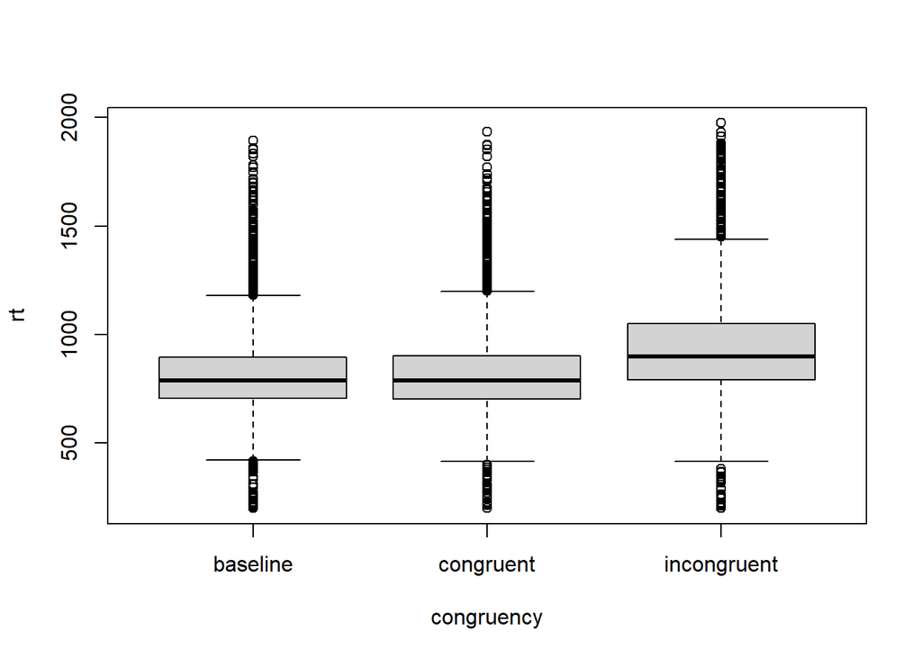

```r
boxplot(rt ~ congruency, stroop)
```

The boxplot shows that on average, the reaction time in the congruent and the baseline condition are practically the same. The variance for these two conditions are also very similar. The incongruent coondition shows the greatest reaction time, as expected. It also shows the greatest variance.

A linear model can determine whether there is a significant difference for phase on reaction time.

```r
stroop_phase <- lm(rt ~ phase, stroop)
summary(stroop_phase)
```

```
##
## Call:
## lm(formula = rt ~ phase, data = stroop)
##
## Residuals:
##     Min      1Q  Median      3Q     Max
## -653.29 -123.29  -30.29   93.71 1120.71
##
## Coefficients:
##               Estimate Std. Error t value Pr(>|t|)
## (Intercept)    852.069      1.852 460.192   <2e-16 ***
## phasestanding    1.217      2.600   0.468     0.64
## ---
## Signif. codes:  0 '***' 0.001 '**' 0.01 '*' 0.05 '.' 0.1 ' ' 1
##
## Residual standard error: 204.2 on 24671 degrees of freedom
## Multiple R-squared:  8.882e-06,  Adjusted R-squared:  -3.165e-05
## F-statistic: 0.2191 on 1 and 24671 DF,  p-value: 0.6397
```

Model reveals no significant difference in reaction time between those standing and those sitting (*p* > 0.05). What about the effect of congruency on reaction time?

```r
stroop_congruency <- lm(rt ~ congruency, stroop)
summary(stroop_congruency)
```

```
##
## Call:
## lm(formula = rt ~ congruency, data = stroop)
##
## Residuals:
##     Min      1Q  Median      3Q     Max
## -733.19 -116.19  -26.19   92.13 1121.42
##
## Coefficients:
##                       Estimate Std. Error t value Pr(>|t|)
## (Intercept)            812.873      2.159 376.423   <2e-16 ***
## congruencycongruent     -0.289      3.055  -0.095    0.925
## congruencyincongruent  120.319      3.060  39.319   <2e-16 ***
## ---
## Signif. codes:  0 '***' 0.001 '**' 0.01 '*' 0.05 '.' 0.1 ' ' 1
##
## Residual standard error: 196.1 on 24670 degrees of freedom
## Multiple R-squared:  0.07717,    Adjusted R-squared:  0.0771
## F-statistic:  1032 on 2 and 24670 DF,  p-value: < 2.2e-16
```

As expected, only the difference between the incongruent and baseline condition were significant. (*p* < .05) Finally, We can then look at the influence on whether starting trials sitting or standing can have influence reaction time.

```r
stroop_condition <- lm(rt ~ condition, stroop)
summary(stroop_condition)
```

```
##
## Call:
## lm(formula = rt ~ condition, data = stroop)
##
## Residuals:
##     Min      1Q  Median      3Q     Max
## -663.57 -127.52  -30.52   94.48 1132.48
##
## Coefficients:
##             Estimate Std. Error t value Pr(>|t|)
## (Intercept)  819.467      4.121 198.875   <2e-16 ***
## condition     22.052      2.596   8.494   <2e-16 ***
## ---
## Signif. codes:  0 '***' 0.001 '**' 0.01 '*' 0.05 '.' 0.1 ' ' 1
##
## Residual standard error: 203.9 on 24671 degrees of freedom
## Multiple R-squared:  0.002916,   Adjusted R-squared:  0.002876
## F-statistic: 72.15 on 1 and 24671 DF,  p-value: < 2.2e-16
```

# 3 The dimensions of popular music

```r
Spotify <- read_csv("spotify_cleaned.csv")
```

First we can start by removing all information that is not relevant to our replication. By referring to the article, we can see which variables they selected for their PCA.

```r
Spotify <- select(Spotify, -time_signature, -X1, -"Track Name", -Artist, -Streams)
```

Now we can run the PCA.

```r
PCA <- prcomp(Spotify)
summary(PCA)
```

```
## Importance of components:
##                            PC1     PC2     PC3    PC4     PC5     PC6     PC7
## Standard deviation     38.6494 28.8325 3.74060 1.9357 0.46579 0.20839 0.18091
## Proportion of Variance  0.6375  0.3548 0.00597 0.0016 0.00009 0.00002 0.00001
## Cumulative Proportion   0.6375  0.9923 0.99826 0.9999 0.99995 0.99997 0.99998
##                            PC8   PC9    PC10    PC11    PC12
## Standard deviation     0.11927 0.104 0.09086 0.07812 0.01857
## Proportion of Variance 0.00001 0.000 0.00000 0.00000 0.00000
## Cumulative Proportion  0.99999 1.000 1.00000 1.00000 1.00000
```

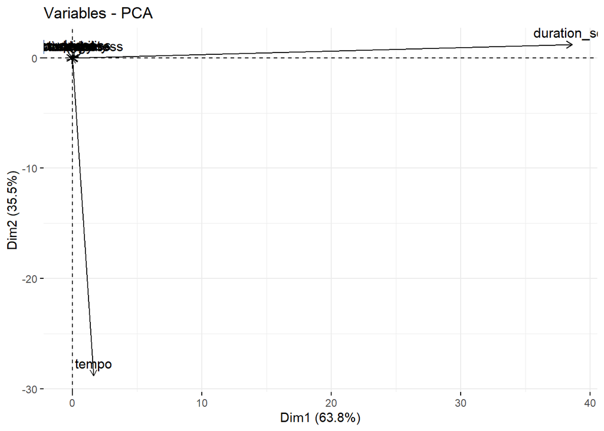

```r
fviz_pca_var(PCA)
```

What happens when we standardise the variables? One problem is that the variables were not standardised in the original analysis, which could be why duration_sec is explaining majority of the variance (as well as tempo). We can standardise all the variable and rurun the PCA.

```r
Spotify_s <- mutate(Spotify,
valence = scale(valence),
acousticness = scale(acousticness),
loudness = scale(loudness),
energy = scale(energy),
danceability = scale(danceability),
tempo = scale(tempo),
duration_sec = scale(duration_sec),
key = scale(key),
mode = scale(mode),
speechiness = scale(speechiness),
instrumentalness = scale(instrumentalness),
liveness = scale(liveness))
```

```r
PCA_s <- prcomp(Spotify_s)
summary(PCA_s)
```

```
## Importance of components:
##                           PC1    PC2    PC3     PC4     PC5     PC6     PC7
## Standard deviation     1.5430 1.2644 1.1556 1.08635 1.03529 0.95780 0.91431
## Proportion of Variance 0.1984 0.1332 0.1113 0.09835 0.08932 0.07645 0.06966
## Cumulative Proportion  0.1984 0.3316 0.4429 0.54126 0.63058 0.70703 0.77669
##                            PC8     PC9    PC10   PC11    PC12
## Standard deviation     0.88167 0.81310 0.79084 0.6187 0.48270
## Proportion of Variance 0.06478 0.05509 0.05212 0.0319 0.01942
## Cumulative Proportion  0.84147 0.89657 0.94869 0.9806 1.00000
```

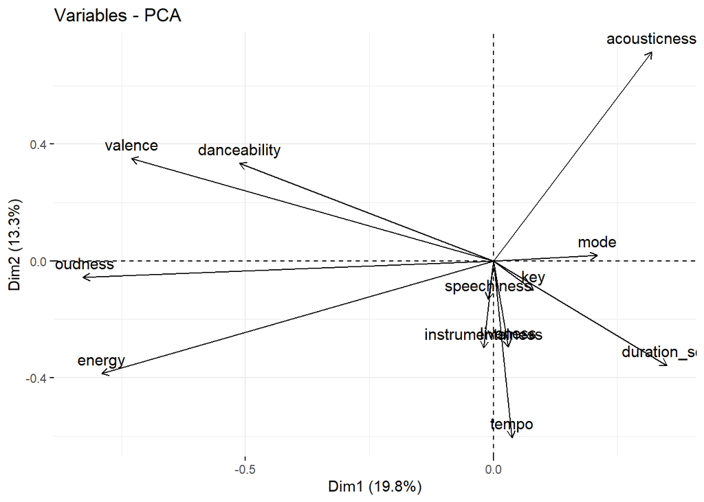

```r
fviz_pca_var(PCA_s)
```